# Correlation Graph, Community Detection, and Graph Manipulation

Steven Surya Tanujaya

July 4, 2019

The objective here is to cluster the city in Swiss based on the given attributes using correlation network. First, we need to filter city/row with very high correlation to (at least one) other city.

This documentation can also be accessed in my Kaggle kernel, [here](https://www.kaggle.com/stevensurya/clustering-using-correlation-network)

```r
library(tidygraph)
library(ggraph)
library(corrr)
library(tidyverse)
swiss.cor <- swiss %>%    # t() for matrix transpose
  t() %>% correlate() %>%    # correlate() is equivalent to cor() but                                                put NA as its diagonal entry and different class
  shave(upper = TRUE) %>%            # Shave the data frame to lower triangular matrix
  stretch(na.rm = TRUE) %>%
  filter(r >= 0.99)
```

```
##
## Correlation method: 'pearson'
## Missing treated using: 'pairwise.complete.obs'
```

```r
swiss.cor
```

```
## # A tibble: 64 x 3
##    x            y                r
##    <chr>        <chr>        <dbl>
##  1 Courtelary   Le Locle     0.991
##  2 Delemont     Franches-Mnt 0.996
##  3 Delemont     Sarine       0.994
##  4 Franches-Mnt Sarine       0.996
##  5 Neuveville   Grandson     0.991
##  6 Neuveville   Val de Ruz   0.992
##  7 Porrentruy   Sarine       0.992
##  8 Broye        Glane        0.996
##  9 Broye        Veveyse      0.996
## 10 Broye        Monthey      0.995
## # ... with 54 more rows
```

```r
#Create tbl_graph object
library(tidygraph)
library(ggraph)
set.seed(100)
swiss.graph <- as_tbl_graph(swiss.cor, directed = FALSE)

# There are 11 city missing, which means they have weak correlation to other city
swiss.graph %>% activate(nodes) %>% as.data.frame() %>% nrow()
```

```
## [1] 36
```

```r
nrow(swiss)
```

```
## [1] 47
```

```
## Using `nicely` as default layout
```

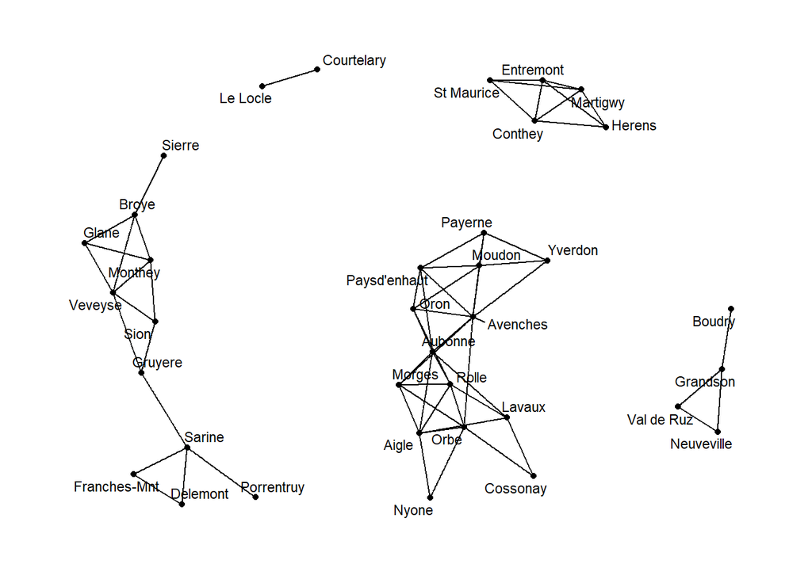

```r
#visualize the network
ggraph(swiss.graph) +
  geom_edge_link() +
  geom_node_point() +
  geom_node_text(
    aes(label = name), size = 3, repel = TRUE
    ) +
  theme_graph()
```

First, let compare the k-means result to the network components.

```r
set.seed(1)
swiss.clust<-kmeans(swiss,4)
```

We want to color the network by `cluster`, here we can apply `join` to graph object.

```r
swiss.group <- data_frame(
  name = rownames(swiss),
  group = as.factor(swiss.clust$cluster)
)
```

```r
swiss.graph <- swiss.graph %>%
  activate(nodes) %>%
  left_join(swiss.group, by = "name") %>%
  rename(label = name) %>%
  activate(edges) %>%
  rename(weight=r)
```

```
## Using `nicely` as default layout
```

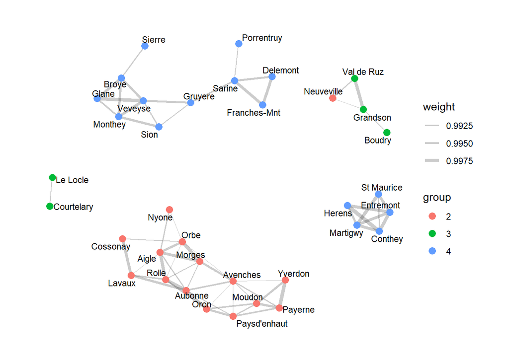

```r
set.seed(100)
ggraph(swiss.graph) +
  geom_edge_link(aes(width = weight), alpha = 0.2) +
  scale_edge_width(range = c(0.2, 1.8)) +
  geom_node_point(aes(color = group), size = 3) +
  geom_node_text(aes(label = label), size = 3, repel = TRUE) +
  theme_graph()
```

How about the negative correlation?

```r
swiss.cor2 <- swiss %>%
  t() %>% correlate() %>%
  shave(upper = TRUE) %>%
  stretch(na.rm = TRUE) %>%
  filter(r < 0)
```

```
##
## Correlation method: 'pearson'
## Missing treated using: 'pairwise.complete.obs'
```

```r
swiss.cor
```

```
## # A tibble: 64 x 3
##    x            y                r
##    <chr>        <chr>        <dbl>
##  1 Courtelary   Le Locle     0.991
##  2 Delemont     Franches-Mnt 0.996
##  3 Delemont     Sarine       0.994
##  4 Franches-Mnt Sarine       0.996
##  5 Neuveville   Grandson     0.991
##  6 Neuveville   Val de Ruz   0.992
##  7 Porrentruy   Sarine       0.992
##  8 Broye        Glane        0.996
##  9 Broye        Veveyse      0.996
## 10 Broye        Monthey      0.995
## # ... with 54 more rows
```

```
## Using `nicely` as default layout
```

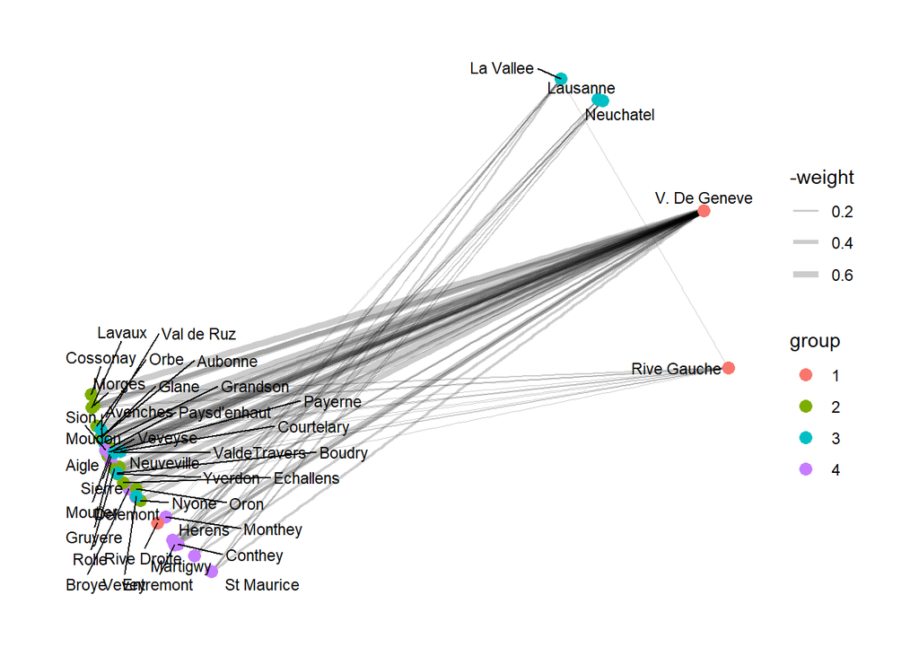

```r
set.seed(100)
swiss.graph2 <- as_tbl_graph(swiss.cor2, directed = FALSE)

swiss.graph2 <- swiss.graph2 %>%
  activate(nodes) %>%
  left_join(swiss.group, by = "name") %>%
  rename(label = name) %>%
  activate(edges) %>%
  rename(weight=r)

set.seed(100)
ggraph(swiss.graph2) +
  geom_edge_link(aes(width = -weight), alpha = 0.2) +
  scale_edge_width(range = c(0.2, 1.8)) +
  geom_node_point(aes(color = group), size = 3) +
  geom_node_text(aes(label = label), size = 3, repel = TRUE) +
  theme_graph()
```

community detection can be applied using `group_*` some of them using edges and some using node as their calculation

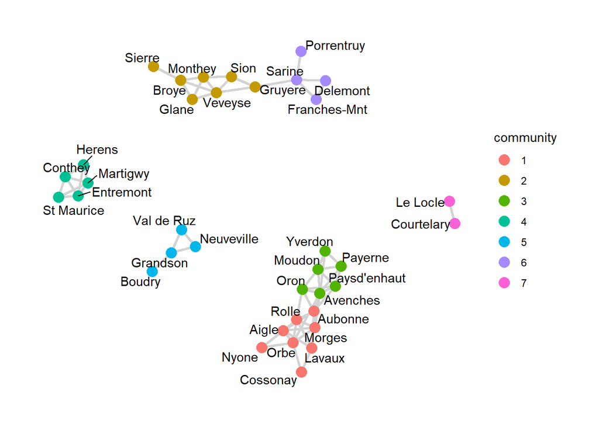

```r
set.seed(100)
swiss.graph %>%
  activate(nodes) %>%
   mutate(community = as.factor(group_infomap())) %>%
  ggraph(layout = "graphopt") +
  geom_edge_link(width = 1, colour = "lightgray") +
  geom_node_point(aes(colour = community), size = 4) +
  geom_node_text(aes(label = label), repel = TRUE)+
  theme_graph()
```

This result show us better cluster for our data. Compared to k-means, this method is more reliable since it is not just only consider the value of each node but also its pattern (in this case: correlation).

Reference:

- http://www.sthda.com/english/articles/33-social-network-analysis/136-network-analysis-and-manipulation-using-r/